# Cluster analysis

## Introduction

- Categorization :
  - Technique-centered : distance-based (partitioninig, hierarchical), density-based (+grid-based), probabilistic, ….
  - Data type-centered : num, categ, text, multimedia, network, time series,…
  - Additional insight-centered : visual insights, semi-supervised, ensemble-based, validation-based

## Similarity Measures

- Good clustering :
  - High intra-class similarity (cohesion)
  - Low inter-class similarity (distinction)
- Similarity measure/function : higher value = more alike (often in the range [0 ; 1])
- Dissimilarity/distance measure : +/- inverse of similarity, lower value = more alike (often in the range [0 ; 1] or [0 ; $\infty$])

### Distance numeric data (Minkowski)

- Data matrix : n data points (rows), d dimensions/attributes (columns)
- Dissimilarity matrix : n x n, with distances d(i, j) => usually symmetric, triangular
- Minkowski : $\sqrt[p]{\sum_{d}{|x_{i,d}-x_{j,d}|^{p}}}$
- Properties (=> metric) :
  - positivity : > 0 if i not j, = 0 if i
  - symmetry : d(i,j) = d(j,i)
  - triangle inequality : d(i,j) <= d(i,m) + d(m,j)
- Special cases :
  - Manhattan : p = 1 (Hamming = Manhattan but with bits)
  - Euclidean : p = 2
  - Supremum distance : p = $\infty$ => max distance for 1 attribute $max|x_{i,d}-x_{j,d}|$

### Proximity for symmetric/asymmetric binary variables

- Contingency table (d attributes with binary values) : rows = 1/0, columns = 1/0, row X column = nb of attributes where value row and value column observed NB : d attributes => total table = d
- Symmetric : distance = nb different / nb tot
- Asymmetric : distance = nb different / nb tot (without 0-0 case)
- Jaccard coefficient (similarity for asym.) : nb same(without 0-0 case) / nb tot(without 0-0 case)

### Distance between Categorical Attributes Ordinal Attributes and Mixed Types

- Categorical attributes : + method 1 : nb missmatches / nb tot + method 2 : binary attribute for each of the categories => cf binary variables
- Ordinal variables : + replace value by interval-scaled variable [0 ; 1] : (rank-1) / (max(rank) -1) + distance = abs difference in i.s. variable
- Mixed types : + weighted average of the distances

### Proximity between 2 vectors (cosine)

- Text document => bag of words, each attribute = word / value = frequency => vector of frequencies
- Cosine : $cos(d1, d2)=\frac{d1\cdot d2}{||d1||\times||d2||}$, $||d1||$ = length of d1 = $\sum_{i}d1_{i}^{2}$$
- Dot product d1,d2 = $\sum_{i}{(d1_{i}\times d2_{i})}$

### Correlation between 2 variables

- Correlation coeff = covar(x1,x2) / std(x1)*std(x2)

## Partitioning-Based Clustering Methods

- K-partitioning : group n obs in K groups/clusters => optimize objective function e.g. $SSE(C)=\sum_{k=1}^{K}\sum_{i\in k}||x_{i}-c_{k}||^{2}$
- $c_{k}$ is the centroid/medoid of cluster $C_{k}$
- Problem = given K, the number of clusters, we want to find a partition of these K clusters that optimize the chosen partitioning criterion, for example, the sum of square distance
- Heuristic : K-means, K-medians, K-medoids => local min/max (global if all partitions tested……)

### K-means

- Each cluster represented by its center (centroid)
- Step 1 : define K points as centroids
- Steps 2 - … : iterate until convergence criterion
  - assign points to closest centroid (distance measure)
  - recompute centroids (means)
- SSE can only improve at each iteration, algo efficient
- **Local optimum** => initialization important
- Need to specify K => often best selected over a range of values
- Sensitivity to noise/outliers => K-medians, K-medoids
- Only works with continuous data => categorical : K-modes
- Not OK with non-convex/non-circular shapes => density-based, kernel K-means, …
- Variants : K-means++, K-medians, K-modes,…
- Feature transformation techniques to cluster non-convex shapes : weighted K-means, kernel K-means
- Initalization :
  - Different initializations may generate rather different clustering results, some may lead to poor results
  - Multiple random starts => best SSE
  - K-means++ : 1st centroid random, others as far as possible
- K-medoids (e.g. PAM) :
  - Medoid = most centrally located **point**
  - Compute new medoid : iterate
    - select point randomly, check if better medoid (SSE)
    - if yes, replace medoid and reassign points
  - Cannot scale well !
  - To improve efficiency : CLARA (PAM on sample), CLARAS (partial resampling at each iteration)
- K-medians, K-modes :
  - K-medians : less sensitive to outliers + Median of cluster as centroid (median of each dimension => not always an existing point !) + Distance = Manhattan + Criterion function : sum(absolute distances) $\sum_{k}\sum_{i\in k}\sum_{d}{|x_{i,d}-med_{k,d}|}$
  - K-modes : modes instead of means
    - Distance measure frequency based, for 1 attribute d :
      - if $x_{d}<>c_{d}$ : $1$
      - if $x_{d}=c_{d}$ : $1-\frac{n_{d}^{r}}{n_{d}}$, 1-part obs avec même valeur r
  - others : fuzzy K-modes, K-Prototype
- Kernel K-means : —- A REVOIR —-
  - for clusters not linearly separable => project data onto high-dim kernel space (kernel function)
  - need to compute n x n kernel matrix
  - kernel functions : polynomial, gaussian radial basis, sigmoid
  - K-means applied to n x n kernel matrix

[output not shown]

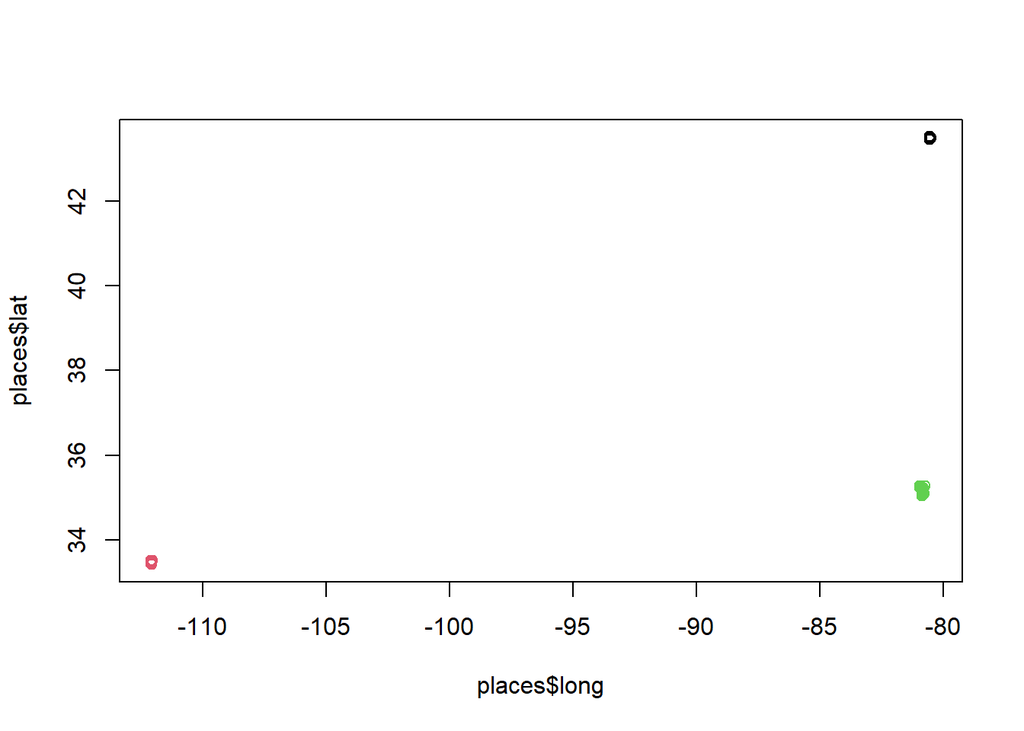

## Hierarchical Clustering Methods

- Clustering hierarchy through merges (agglomerative) or splits (divisive) => graph representation = dendogramm
- K not defined a priori (hierarchy = several levels for K)

### Agglomerative (AGNES)

- Bottom-up :
  - start = single obj clusters => continuously merge nodes with least dissimilarity
  - end = 1 cluster (all in the same)
- Similarity measures :
  - single link : distance between nearest neighbours (points within cluster)
    - local similarity-based
    - ignores overall structure of cluster
    - sensitive to noise/outliers
  - complete link : distance between farthest neighbours (points within cluster) / diameter
    - result = new cluster with smalles diameter
    - nonlocal behavior, compact shaped clusters
    - sensitive to noise/outliers
  - average link : average distance between all points
    - expensive to compute
  - centroid link : distance between centroids
- Group averaged agglomerative clustering (GAAC) : at each step, centroid of new cluster = weighted mean of centroids of previous clusters
- Ward’s criterion : loss in SSSE when agregating, for clusters a and b, $\frac{N_{a}\cdot N_{b}}{N_{a}+N_{b}}d(C_{a}, C_{b})$

### Extensions

- Major issues
  - sequential, previous stage cannot be undone
  - do not scale well
- Extensions : BIRCH (1996), CURE (1998), CHAMELEON (1999)

### BIRCH

**TOUTE LA SUITE A REVOIR**

- Multiphase, incrementally construct a CF (Clustering Featur) tree
  - Phase 1 : build initial CF tree
  - Phase 2 : use an arbitrary clustering algo on the leaves
- Scales linearly
- For 1 cluster, CF = 3 components :
  - number of data points
  - linear sum of points for each feature/dimension
  - square sum of points for each feature/dimension
- 3 measures of clusters can be computed from CF (efficiency in storage) :
  - centroid = sum of points / nb
  - diameter = avg distance from points to the centroid (squared !)
  - radius = avg pairwise distance within cluster
- CF are additive
- CF tree structure :
  - for each new point
    - add to closest leaf, update CF
    - if diameter > max_diameter, split leaf and possibly parents
  - 2 parameters :
    - branching factor = max nb of children
    - max diameter of subclusters at the leaf nodes
- Concerns :
  - tree is still sensitive to the insertion order of the data points
  - since the leaf nodes has a fixed size, the clustering obtained may not be as natural
  - the clusters tend to be spherical given the radius and diameter measure as the major parameters

### CURE

- CURE actually represents a cluster using a set of well scattered representative points
- Cluster distance : min between representative points chosen
  - characteristics of single- and average-linking
- Shrinking factor $\alpha$ towards centroid
  - Impact of outliers lower

### CHAMELEON

- Graph partitionning based on k-NN graph of the data
- Agglo hierarch algo :
  - clusters merged only if interconnectivity + proximity between clusters high relative to interconnectivity + proximity within clusters
    - above threshold
    - max function that combines both
  - start = graphlets based on k-NN graphs (each point connected with k closest points)
- Interconnectivity = sum weights(edges)
- Proximity = avg weights(edges)
- Can cluster complex objects

### Probabilistic hierarchical

- Problems with hierarchical algos :
  - choice of distance measure
  - hard to handle missing values
  - optimization goal not clear (heuristic)
- Probabilistic model to measure distance
- Data = generative model based on common distribution functions => max likelihood !
- Quality of clustering = likelihood clustering ($\prod_{k}L(C_{k})$)
- Distance betwween clusters : $d(C_{1}, C_{2})=-log(\frac{L(C_{1}\cup C_{2})}{L(C_{1})L(C_{2})})$, where L = maxlikelihood => merge if d(C1,C2) < 0

## Density-based Clustering Methods

- Density-based :
  - local cluster criterion
  - discover clusters of arbitrary shapes
  - can handle noise
  - only examine local region to justify density
  - need density parameter as termination criterion

### DBSCAN

- Cluster = max set of density-connected points
- 2 params :
  - eps = max radius of neighbourhood
  - minpts = min points in the neighbourhood
  - Eps-neighbourhood : $N_{eps}(q)\{ p | dist(p,q) \le eps\}$
- Core point : dense neighborhood (Eps-neighbourhood >= minpts)
- Border point : in cluster but not dense (*dr* from core point)
- Outlier/noise : not in any cluster
- Concepts :
  - directly density-reachable (*ddr*) : p *ddr* from q if
    - p belongs to $N_{eps}(q)$
    - q is a core point
  - density-reachable (*dr*) : p *dr* from q if chain of points $p_{1}$=q, …. $p_{n}$=p so that $p_{i+1}$ is *ddr* from $p_{i}$ NB : $p_{i}$ is a core point and $p_{i+1}$ belongs to $N_{eps}(p_{i})$ => all $p_{i=1,...n-1}$ are core points !
  - density-connected (*dc*) : p *dc* to q if point o so that p and r *dr* from o NB : point o is a core point as well as all points between o and p / between o and q
- Algo :
  - Randomly select p
  - Find all points *dr* from p
    - if p is a core point, cluster with all *dr* points
    - if p not a core point, no *dr* points => start with next point not clustered
  - Continue until all points have been processed
- Algo :
  - Efficient
  - Sensitive to setting of params

### OPTICS

**TOUTE LA SUITE A REVOIR**

- Ordering Points To Identify Clustering Structures
- DBSCAN extended to be less sensitive to params
- Given minpts, higher-density clusters completely contained in clusters with lower density
- Higher density points should be treated first
- 2 infos for each point to store clustering structure :
  - core distance : smallest eps to reach minpts for p
  - reachability distance (of p from core q) : min eps that makes p *dr* from q =>
    - undefined if q not a core
    - else max(core-dist(q), dist(p,q))
- Reachability plot (objects vs reachability distance) : valley = clusters, deeper the valley => denser the cluster
- Cluster-ordering of the data points, ynested clusters can be seen (valleys in valley)

### Grid-based

- Partition data space into a finite number of cells => grid structure (multi-resolution)
- Find clusters from the cells
- Efficient, scalable : nb of cells << nb of data
- Hard to handle highly irregular data distributions
- Limited by predefined cell sizes, density threshold
- Curse of dimensionality

### STING

- StatisticalInformationGrid
- Cells at different levels of resolutions => tree structure

### CLIQUE

- Grid-based subspace clustering
  - Grid-based : grid, density estimated with nb of points
  - Density-based : dense if nb of points > model parameter
  - Subspace clustering : subspace cluster = set of neighboring dense cells
- Steps :
  - identify subspaces that contain clusters (Apriori principles)
  - identify clusters
  - generate min descriptions for the clusters

## Methods for clustering validation

- Clustering quality : goodness of clustering results
  - external : supervised, compare clustering with a priori / expert knowledge
  - internal : unsupervised, derived from the data themselves (separation between clusters, how compat)
  - relative measures : compare different clusterings (usually same algo / different parameters)
- Clustering stability : sensitivity to various parameters
- Clustering tendency : clustering suitable ? inherent grouping structure ?

### External measures

- Quality function Q(T, C) : 4 criteria
  - cluster homogeneity : the purer, the better
  - cluster completeness : objects in same true category in same cluster
  - rag bag better than alien : penalization if heterogeneous object put into a pure cluster instead of into a “rag bag” (misc.)
  - small cluster preservation : splitting small cluster more harmful than large cluster
- Matching-based measures :
  - purity : k real clusters (j), r estimated clusters (i)
    - purity for cluster $C_{i}$ : $pur_{i}=\frac{1}{n_{i}}max_{j=1}^{k}(n_{i,j})$
    - total purity : $pur=\sum_{i=1}^{r}(\frac{n_{i}}{n}pur_{i})=\frac{1}{n}\sum_{i=1}^{r}(max_{j=1}^{k}(n_{i,j}))$
    - perfect purity if purity = 1 and r = k
    - different estimated clusters may have max purity for (reflect) the same true group ! => maximum-matching to solve this
  - maximum-matching :
    - only one cluster can match one true group
    - max purity with that constraint
  - F-measure :
    - precision $C_{i}$: cf purity $\frac{1}{n_{i}}max_{j=1}^{k}(n_{i,j})$
    - recall $C_{i}$ : $\frac{n_{i,j}}{\sum_{i=1}^{r}{n_{i,j}}}$ with j as $arg max_{j}(n_{i,j})$ NB : share of obs in real cluster j recovered in i
    - F = harmonic mean precision and recall $F_{i}=\frac{2n_{i,j}}{(n_{i,j}+\sum_{i}(n_{i,j})}$ => F=$\frac{1}{r}\sum_{i=1}^{r}F_{i}$
- Entropy-based measures :
  - Information theory measure used also in Datamining, ML,…
  - Entropy of clustering C : $H(C)=-\sum_{i=1)}^{r}p(C_{i})log(p(C_{i}))$, $p(C_{i})=\frac{n_{i}}{n}$
  - Entropy of partitioning T (real clusters) : $H(T)=-\sum_{j=1)}^{k}p(T_{j})log(p(T_{j}))$
  - Entropy of T with respect to cluster $C_{i}$ : $H(T|C_{i})=-\sum_{j=1)}^{k}(\frac{n_{i,j}}{n_{i}})log(\frac{n_{i,j}}{n_{i}})$
  - Conditional entropy of T with respect to clustering C : $H(T|C)=-\sum_{i=1}^{r}(\frac{n_{i}}{n})H(T|C_{i})=-\sum_{i=1}^{r}\sum_{j=1}^{k}p_{i,j}log(\frac{p_{i,j}}{p(C_{i})})$
  - The more of a cluster’s membership has split into different partitions, the higher the conditional entropy
  - Perfect clustering : entropy = 0, worst = log(k)
  - Normalized mutual information :
    - Mutual info = amount of shared info between C and T : $I(C,T)=\sum_{i=1}^{r}\sum_{j=1}^{k}p_{i,j}log(\frac{p_{i,j}}{p(C_{i})p(T_{j})})$
    - If C and T independant, $p_{i,j}=p(C_{i})p(T_{j})$ and I(C,T) = 0 ! No upper bound
    - Normalized MI : min = 0, max = 1 $NMI(C,T)=\frac{I(C,T)}{\sqrt{H(C)H(T)}}$
- Pairwise measures :
  - 4 possibilities of agreement between C and T : TP, TN, FP, FN
  - TP = same C AND same T,…. FN = different C AND same T (**! nb of pairs not of observations !**)
  - $TP=\sum_{i}\sum_{j}\binom{n_{i,j}}{2}$ : toutes les paires dans les mêmes clusters et les mêmes partitions
  - $FN=\sum_{j}\binom{m_{j}}{2}-TP$ : toutes les paires dans différents clusters et les mêmes partitions (toutes les paires dans les mêmes partitions - TP)
  - $FP=\sum_{i}\binom{n_{i}}{2}-TP$ toutes les paires dans les mêmes clusters et différentes partitions (toutes les paires dans les mêmes clusters - TP)
  - $TN=N-(TP+FN+FP)$ toutes lea paires dans différents clusters et différentes partitions
  - total nb of obs = $\binom{n}{2}$
  - Jaccard Coefficient : TP / (TP + FP + FN)
  - Rand Stat : (TP + TN) / N
  - Fowlkes-Mallow measure : $\frac{TP}{\sqrt{(TP+FN)(TP+FP)}}$

### Relative measures

- Directly compare different clusterings (usually different parameters, same algo)
- Silhouette coefficient as an internal measure :
  - for each point $x_{i}$, $s_{i}=\frac{\mu_{out}^{min}(x_{i})-\mu_{in}(x_{i})}{max\{\mu_{out}^{min}(x_{i}),\mu_{in}(x_{i})\}}$
  - $mu_{out}^{min}(x_{i})$ = mean distance between $x_{i}$ and points in the closest cluster
  - $mu_{in}(x_{i})$ = mean distance between $x_{i}$ and other points in the same cluster
  - Silhouette coefficient : $\frac{1}{n}\sum_{i}s_{i}$
- Silhouette coefficient as a relative measure : estimate nb of clusters => pick k value with highest coefficient SC

### Cluster stability

- Clustering ok if stable results => samples, compare results
- Useful to find good parameter values
- Bootstrapping approach to find best value of k :
  - t samples of size n with replacement
  - for each sample $D_{i}$, run same algo with k = 2,…max_k
  - compare distances between all pairs of clusterings $C_{k}(D_{i})$ and $C_{k}(D_{j})$ => expected distance for k
  - k* = k with smallest distance
- Other methods to find right k :
  - empirical method : $k=\sqrt{n/2}$, ok if small n
  - elbow method : graph sum(within cluster variance) vs k => k* = when elbow (decrease gets slower)
  - cross-validation : k* = best SSE on the “test” sets

### Clustering tendency / Clusterability

- Whether the data contains inherent group structure
- Different algos = different definitions of clusters
- Methods :
  - spatial histograms (d-dimensionals) : histo data vs random sample => Kullback-Leibler divergence
  - distance distribution : pairwise distance vs random sample
  - Hopkins statistic